# Main.py

```python
lunch = GroupLunch()
```

Below we can see the preference vector for each individual (normalized to 1).

```python
lunch.printPreferences()
```

```
Name: Liam
Distance: 0.026
Cost: 0.158
Rating: 0.184
Vegitarian: 0.263
Experimental: 0.000
Indian: 0.158
Hipster: 0.079
Mexican: 0.132


Name: Noah
Distance: 0.083
Cost: 0.194
Rating: 0.083
Vegitarian: 0.250
Experimental: 0.028
Indian: 0.194
Hipster: 0.111
Mexican: 0.056


Name: William
Distance: 0.257
Cost: 0.057
Rating: 0.114
Vegitarian: 0.114
Experimental: 0.000
Indian: 0.143
Hipster: 0.057
Mexican: 0.257


Name: James
Distance: 0.098
Cost: 0.146
Rating: 0.122
Vegitarian: 0.195
Experimental: 0.000
Indian: 0.171
```

[output cut: 53 more lines]

```
Experimental: 0.000
Indian: 0.074
Hipster: 0.111
Mexican: 0.037


Name: Anne
Distance: 0.152
Cost: 0.174
Rating: 0.065
Vegitarian: 0.174
Experimental: 0.000
Indian: 0.043
Hipster: 0.196
Mexican: 0.196
```

Below we can see the profile for each restaurant (Score/10).

```python
lunch.printProfiles()
```

```
Name: Gonza
Distance: 1.00
Cost: 1.00
Rating: 0.40
Vegitarian: 0.70
Experimental: 0.10
Indian: 0.40
Hipster: 0.80
Mexican: 0.10


Name: Pizzeria
Distance: 0.10
Cost: 0.60
Rating: 0.60
Vegitarian: 0.70
Experimental: 0.00
Indian: 0.60
Hipster: 0.60
Mexican: 0.40


Name: Refectory
Distance: 0.40
Cost: 0.90
Rating: 0.60
Vegitarian: 1.00
Experimental: 0.00
Indian: 0.10
Hipster: 0.90
Mexican: 0.80


Name: Fosters
Distance: 0.10
Cost: 0.60
Rating: 0.10
Vegitarian: 0.30
Experimental: 0.00
Indian: 0.70
```

[output cut: 53 more lines]

```
Experimental: 0.00
Indian: 0.70
Hipster: 0.20
Mexican: 0.90


Name: Vin Rouge
Distance: 0.50
Cost: 0.50
Rating: 0.20
Vegitarian: 0.30
Experimental: 0.10
Indian: 0.90
Hipster: 0.30
Mexican: 0.60
```

#### Linear Combination

A linear combination is a way to represent a score (preference) for a particular feature (property). This information can easily be represented in a matrix format. Assuming a matrix of M rows x features, then the Mth row represents Mth's preferences and each column represents Mth's preference for that specific property of a restaurant.

#### Individual Preferences

Liam's ideal pick based on preferences. Each value in the vector represents the order of preference for each restaurant in the list of available restaurants. The higher the value, the more preferred choice.

```python
lunch.specificChoiceByPreference("Liam")
```

```
Restaurant 'Gonza': 0.58
Restaurant 'Pizzeria': 0.59
Restaurant 'Refectory': 0.72
Restaurant 'Fosters': 0.42
Restaurant 'Bach': 0.36
Restaurant 'JuJu': 0.49
Restaurant 'Mateo': 0.71
Restaurant 'Rue Cler': 0.54
Restaurant 'Blue Olive': 0.42
Restaurant 'Vin Rouge': 0.45
Liam would prefer Refectory
```

```
array([0.58157895, 0.58684211, 0.71842105, 0.41578947, 0.36315789,
       0.49473684, 0.71315789, 0.54210526, 0.42105263, 0.45263158])
```

Each individual's ideal preference

```python
lunch.individualChoice()
```

```
Restaurant 'Gonza': 0.58
Restaurant 'Pizzeria': 0.59
Restaurant 'Refectory': 0.72
Restaurant 'Fosters': 0.42
Restaurant 'Bach': 0.36
Restaurant 'JuJu': 0.49
Restaurant 'Mateo': 0.71
Restaurant 'Rue Cler': 0.54
Restaurant 'Blue Olive': 0.42
Restaurant 'Vin Rouge': 0.45
Liam would prefer Refectory


Restaurant 'Gonza': 0.66
Restaurant 'Pizzeria': 0.56
Restaurant 'Refectory': 0.67
Restaurant 'Fosters': 0.42
Restaurant 'Bach': 0.32
Restaurant 'JuJu': 0.53
Restaurant 'Mateo': 0.64
Restaurant 'Rue Cler': 0.58
Restaurant 'Blue Olive': 0.42
Restaurant 'Vin Rouge': 0.47
Noah would prefer Refectory


Restaurant 'Gonza': 0.57
Restaurant 'Pizzeria': 0.43
Restaurant 'Refectory': 0.61
Restaurant 'Fosters': 0.38
Restaurant 'Bach': 0.53
Restaurant 'JuJu': 0.61
Restaurant 'Mateo': 0.68
Restaurant 'Rue Cler': 0.60
Restaurant 'Blue Olive': 0.51
Restaurant 'Vin Rouge': 0.51
William would prefer Mateo


Restaurant 'Gonza': 0.56
```

[output cut: 73 more lines]

```
Restaurant 'Vin Rouge': 0.44
Sophia would prefer Gonza


Restaurant 'Gonza': 0.67
Restaurant 'Pizzeria': 0.50
Restaurant 'Refectory': 0.77
Restaurant 'Fosters': 0.40
Restaurant 'Bach': 0.47
Restaurant 'JuJu': 0.59
Restaurant 'Mateo': 0.66
Restaurant 'Rue Cler': 0.51
Restaurant 'Blue Olive': 0.45
Restaurant 'Vin Rouge': 0.44
Anne would prefer Refectory
```

#### Preference Matrix

Below represents each person's prerefence for each restaurant. The value at row i, column j represents ith person's preference for jth restaurant.

```python
lunch.printPrefMatrix()
```

```
Preference Matrix:
[[0.58157895 0.58684211 0.71842105 0.41578947 0.36315789 0.49473684
  0.71315789 0.54210526 0.42105263 0.45263158]
 [0.66111111 0.55555556 0.67222222 0.42222222 0.31944444 0.52777778
  0.64166667 0.57777778 0.41666667 0.475     ]
 [0.56857143 0.43142857 0.60857143 0.38285714 0.53142857 0.60571429
  0.67714286 0.60285714 0.51428571 0.51428571]
 [0.55853659 0.52682927 0.67560976 0.43902439 0.41463415 0.53658537
  0.67317073 0.55609756 0.50487805 0.50487805]
 [0.65128205 0.55128205 0.68461538 0.34615385 0.3974359  0.52820513
  0.7025641  0.58461538 0.36410256 0.42564103]
 [0.64571429 0.44       0.66571429 0.36571429 0.54857143 0.64285714
  0.7        0.57142857 0.44857143 0.46571429]
 [0.81212121 0.49393939 0.75454545 0.34545455 0.44545455 0.62121212
  0.62727273 0.57575758 0.36363636 0.41212121]
 [0.67804878 0.47317073 0.62682927 0.42195122 0.4195122  0.62439024
  0.60243902 0.57073171 0.47804878 0.50731707]
 [0.76666667 0.51481481 0.71481481 0.37407407 0.41481481 0.61851852
  0.5962963  0.54074074 0.4037037  0.43703704]
 [0.6673913  0.50217391 0.7673913  0.40434783 0.46956522 0.58695652
  0.65869565 0.51304348 0.45217391 0.44347826]]
```

#### Group Choice

```python
lunch.groupChoice()
```

```
Restaurant 'Gonza': 5.29
Restaurant 'Pizzeria': 5.27
Restaurant 'Refectory': 5.44
Restaurant 'Fosters': 5.39
Restaurant 'Bach': 5.24
Restaurant 'JuJu': 5.49
Restaurant 'Mateo': 5.45
Restaurant 'Rue Cler': 5.40
Restaurant 'Blue Olive': 5.38
Restaurant 'Vin Rouge': 5.47
The group should go to: JuJu
```

#### Group Choice by Rank

In this instance, we see that the choice has actually changed from 'JuJu' to 'Refectory'. This is because summation down columns can be affected by higher and lower values. A restaurant with consistently above average scores will be the winner even though it isn't anybody's preferred choice in the result above. To account for this issue, we can renormalize our data.

```python
lunch.groupChoiceByRank()
```

```
Restaurant 'Gonza': 75
Restaurant 'Pizzeria': 37
Restaurant 'Refectory': 84
Restaurant 'Fosters': 5
Restaurant 'Bach': 18
Restaurant 'JuJu': 56
Restaurant 'Mateo': 76
Restaurant 'Rue Cler': 54
Restaurant 'Blue Olive': 17
Restaurant 'Vin Rouge': 28
The group should go to: Refectory
```

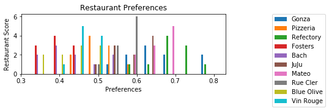

```python
lunch.plotHistogram()
```

#### Clustering

```
Split the group
```

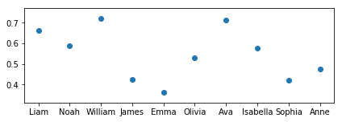

```python
lunch.cluster()
```

#### Boss Paying

If the boss is paying then those concerned about cost no longer need to worry about cost. To adjust for this, we set cost to have a high level of influence on the result. In this instance, we see that if we give cost a greater influence, then the restaurant changes to 'Mateo'.

```python
lunch.bossPaying()
```

```
If the boss is paying:
Restaurant 'Gonza': 59.00
Restaurant 'Pizzeria': 34.00
Restaurant 'Refectory': 71.00
Restaurant 'Fosters': 2.00
Restaurant 'Bach': 30.00
Restaurant 'JuJu': 54.00
Restaurant 'Mateo': 89.00
Restaurant 'Rue Cler': 68.00
Restaurant 'Blue Olive': 15.00
Restaurant 'Vin Rouge': 28.00
The group should go to: Mateo
```

#### Weight Matrix from Restaurant Order

To find the weight matrix for the new group from the restaurant order, we need to multiple the result rankings by the restaurant profiles and normalize.

```python
lunch.computeWeightMatrix()
```

```
[[0.04901375 0.00089659 0.00095637 0.00567842 0.01721458 0.01721458
  0.00866707 0.0096832  0.00334728 0.0260012 ]
 [0.04901375 0.00896593 0.00239091 0.05678422 0.02151823 0.01912732
  0.01733413 0.01075912 0.0083682  0.05200239]
 [0.0196055  0.00537956 0.00143455 0.00567842 0.01291094 0.00956366
  0.01733413 0.00430365 0.00083682 0.01040048]
 [0.03430962 0.00627615 0.00239091 0.01703527 0.00430365 0.00382546
  0.0138673  0.00753138 0.00167364 0.01560072]
 [0.00490137 0.         0.         0.         0.         0.00191273
  0.00173341 0.         0.         0.00520024]
 [0.0196055  0.00537956 0.00023909 0.03974895 0.00215182 0.01147639
  0.01213389 0.0096832  0.00585774 0.04680215]
 [0.00490137 0.00358637 0.00191273 0.03407053 0.01506276 0.00956366
  0.01213389 0.00322773 0.00753138 0.03120143]
 [0.039211   0.00537956 0.00215182 0.02271369 0.01075912 0.01338912
  0.01560072 0.00430365 0.00167364 0.01560072]]
```

# GroupLunch.py

```python
# Import Libraries
import csv
import os
import numpy as np
import matplotlib.pyplot as plt
from sklearn.cluster import KMeans

# Import Classes
from Person import Person
from Restaurant import Restaurant

class GroupLunch(object):
    # Predfined list of names to make things easier
    peopleNames = ["Liam", "Noah", "William", "James", "Emma", "Olivia", "Ava", "Isabella", "Sophia", "Anne"]
    restaurantNames = ["Gonza", "Pizzeria", "Refectory", "Fosters", "Bach", "JuJu", "Mateo", "Rue Cler", "Blue Olive",
                       "Vin Rouge"]

    # Create 2D array to store values
    peopleWeights = np.zeros((10, 8), dtype=float)
    restaurantProperties = np.zeros((10, 8), dtype=float)
    prefResult = np.zeros((10,10), dtype=float)
    rankResult = np.zeros((10, 10), dtype=int)
    winner = np.zeros((1,0), dtype=int)


    # Create lookup and reverse lookup table
    peopleLookup = {}
    peopleReverseLookup = {}
    restaurantLookup = {}

    # Store individual results
    peopleDict = {}
    restDict = {}

    # Result vars
    winnerIdx = -1
    winnerName = ""


    # Generate random values for people preferences and resturant profiles
    # or read from file and re-initialize class instances
    def __init__(self):
        # Credit: https://therenegadecoder.com/code/how-to-check-if-a-file-exists-in-python/
        fileFound = (os.path.isfile('peopleWeights.csv')) and (os.path.isfile('restaurantProfile.csv'))
        if fileFound:
            self.readMatrices()
            self.generateFromFile()
        else:
            self.generateValues()
            self.saveMatrices()

    # Generate random values for people preferences and resturant profiles
    def generateValues(self):
        self.generatePeopleValues()
        self.generateRestaurantValues()
        self.generateRankResults()

    # Generate random values for people preferences
    def generatePeopleValues(self):
        for idx, name in enumerate(self.peopleNames):
            self.peopleLookup[idx] = name

            self.peopleDict[name] = Person(name, idx)

            tmpArr = self.peopleDict[name].getPreferences()

            # Normalize to 1
            # Credit: https://math.stackexchange.com/questions/278418/normalize-values-to-sum-1-but-keeping-their-weights
            normArr = tmpArr / np.sum(tmpArr)

            self.peopleWeights[idx, :] = normArr

    # Generate random values for restaurant profiles
    def generateRestaurantValues(self):
        for idx, name in enumerate(self.restaurantNames):
            self.restaurantLookup[idx] = name

            self.restDict[name] = Restaurant(name, idx)

            tmpArr = self.restDict[name].getProperties()

            normArr = tmpArr / 10

            self.restaurantProperties[idx, :] = normArr

    # Re-initialize class instances from data read from file
    def generateFromFile(self):
        for idx, name in enumerate(self.peopleNames):
            self.peopleLookup[idx] = name

            self.peopleDict[name] = Person(name, idx, self.peopleWeights[idx])

            tmpArr = self.peopleDict[name].getPreferences()

            self.peopleWeights[idx, :] = tmpArr

        for idx, name in enumerate(self.restaurantNames):
            self.restaurantLookup[idx] = name

            self.restDict[name] = Restaurant(name, idx, self.restaurantProperties[idx])

            tmpArr = self.restDict[name].getProperties()

            self.restaurantProperties[idx, :] = tmpArr

        self.generateRankResults()

    # Convert numerical preferences to 0 - 9 ranking
    def generateRankResults(self):
        # Credit: https://stackoverflow.com/questions/5284646/rank-items-in-an-array-using-python-numpy/29059978
        # Credit: https://docs.scipy.org/doc/numpy-1.13.0/reference/arrays.nditer.html
        tmp = np.dot(self.peopleWeights, self.restaurantProperties.transpose())
        for idx, name in enumerate(self.peopleNames):
            self.prefResult[idx, :] = tmp[idx, :]

            tmpRank = tmp[idx, :].argsort()
            self.rankResult[idx, :] = tmpRank.argsort(axis = 0)
            self.peopleReverseLookup[name] = idx

    # Yup, it prints the individuals preferences
    def printWeightMatrix(self):
        for name in self.peopleNames:
            pref = self.peopleDict[name].getPreferences()
            print(f"{name}: {pref}")

    # Same as above no print formatting
    def printPreferences(self):
        for name in self.peopleNames:
            print(f"Name: {name}")
            pref = self.peopleDict[name].printPreferences()

    # Yup, it prints the restaurants profile
    def printProfiles(self):
        for name in self.restaurantNames:
            print(f"Name: {name}")
            pref = self.restDict[name].printProperties()

    # Same as above but not print formatting
    def printRestaurantProperties(self):
        print(self.restaurantProperties)

    # Yup, it prints the ranking matrix
    def printRankResults(self):
        print(f"{self.rankResult}")

    # Yup, it prints the preference matrix
    def printPrefMatrix(self):
        print(f"Preference Matrix:\n{self.prefResult}")

    # Given a name, compute the preferred restaurant by weights
    def specificChoiceByPreference(self, name):
        for idx, restName in enumerate(self.restaurantNames):
            print(f"Restaurant '{restName}': {self.prefResult[self.peopleReverseLookup[name], idx]:.2f}")

        namePref = self.prefResult[self.peopleReverseLookup[name]]
        tmpIdx = np.argmax(namePref)
        print(f"{name} would prefer {self.restaurantLookup[tmpIdx]}")
        return namePref

    # Given a name, compute the preferred restaurant by ranking
    def specificChoice(self, name):
        #tmpPref = self.prefResult[self.peopleReverseLookup[name]]
        for idx, restName in enumerate(self.restaurantNames):
            print(f"Restaurant '{restName}': {self.rankResult[self.peopleReverseLookup[name], idx]}")

        namePref = self.rankResult[self.peopleReverseLookup[name]]
        tmpIdx = np.argmax(namePref)
        print(f"{name} would prefer {self.restaurantLookup[tmpIdx]}")
        return namePref

    # Loop through all names and pass into specificChoice function to determine preferred restaurant
    def individualChoice(self):
        tmpArr = np.zeros((10, 10), dtype=float)
        for idx, name in enumerate(self.peopleNames):
            tmpArr[idx, :] = self.specificChoiceByPreference(name)
            print("\n")

        self.prefResult = tmpArr

    # Sum down the columns, determine maximum score and reverse lookup to find restaurant winner
    def groupChoice(self, pref = None):

        # Sum along column axis
        if pref is None:
            tmpResult = np.sum(self.prefResult, axis = 1)
        else:
            tmpResult = np.sum(pref, axis = 1)

        for idx, value in enumerate(tmpResult):
            print(f"Restaurant '{self.restaurantNames[idx]}': {tmpResult[idx]:.2f}")

        # find the largest value and get index for reverse lookup
        self.winnerIdx = np.argmax(tmpResult)
        self.winnerName = self.restaurantLookup[self.winnerIdx]

        print(f"The group should go to: {self.winnerName}")

    # Same as above but based on ranking values
    def groupChoiceByRank(self, rank = None):
        if rank is None:
            tmpResult = np.sum(self.rankResult.transpose(), axis = 1)
        else:
            tmpResult = np.sum(rank.transpose(), axis = 1)

        for idx, value in enumerate(tmpResult):
            print(f"Restaurant '{self.restaurantNames[idx]}': {tmpResult[idx]}")

        self.winnerIdx = np.argmax(tmpResult)
        self.winnerName = self.restaurantLookup[self.winnerIdx]
        print(f"The group should go to: {self.winnerName}")

    # Show a histogram of restaurant preferences
    def plotHistogram(self):
        plt.subplot(211)
        plt.hist(self.prefResult, label = self.restaurantNames)
        plt.xlabel("Preferences")
        plt.ylabel("Restaurant Score")
        plt.title("Restaurant Preferences")
        plt.legend(bbox_to_anchor=(1.5, 1.05))

    # Apply KMeans clustering to determine if two groups exist upon which to split
    def cluster(self):
        clf = KMeans(n_clusters=2, random_state=42).fit(self.prefResult)

        # If clustering algo groups at least four people to a group, split
        if np.sum(clf.labels_) >= 4:
            print(f"Split the group")

        # Show names and pref calculation
        plt.subplot(212)
        plt.scatter(self.peopleNames, np.max(self.prefResult[clf.labels_], axis = 0))
        plt.tight_layout()
        plt.show()

    # Set cost to most influential value and recalculate restaurant values
    def bossPaying(self):
        self.restaurantProperties[:, 1] = 1
        prefResult = np.zeros((10, 10))
        rankResult = np.zeros((10, 10))
        # Credit: https://stackoverflow.com/questions/5284646/rank-items-in-an-array-using-python-numpy/29059978
        # Credit: https://docs.scipy.org/doc/numpy-1.13.0/reference/arrays.nditer.html
        tmp = np.dot(self.peopleWeights, self.restaurantProperties.transpose())
        for idx, name in enumerate(self.peopleNames):
            prefResult[idx, :] = tmp[idx, :]

            tmpRank = tmp[idx, :].argsort()
            rankResult[idx, :] = tmpRank.argsort(axis=0)

        print(f"If the boss is paying:")
        self.groupChoice(rankResult.transpose())

    # Create a fake restaurant ranking score and compute the weights used for the new group
    # Credit: https://stackoverflow.com/questions/22842289/generate-n-unique-random-numbers-within-a-range
    def computeWeightMatrix(self):
        import random
        random.seed(42)
        restPref = random.sample(range(1, 100), 10)

        tmpResult = []
        for idx, props in enumerate(self.restaurantProperties.transpose()):
            tmpResult.append(restPref * props)

        # Credit: https://math.stackexchange.com/questions/278418/normalize-values-to-sum-1-but-keeping-their-weights
        normArr = tmpResult / np.sum(tmpResult)

        print(normArr)

    # Save individual and restaurant values to file
    # Credit: https://stackoverflow.com/questions/3348460/csv-file-written-with-python-has-blank-lines-between-each-row
    # Credit: https://stackoverflow.com/questions/8685809/writing-a-dictionary-to-a-csv-file-with-one-line-for-every-key-value
    def saveMatrices(self):
        with open('peopleWeights.csv', 'w', newline='') as peopleWeights:
            writer = csv.writer(peopleWeights)
            for value in self.peopleWeights:
                writer.writerow(value)

        with open('restaurantProfile.csv', 'w', newline='') as restProfile:
            writer = csv.writer(restProfile)
            for value in self.restaurantProperties:
                writer.writerow(value)

    # Load individual and restaurant values from file
    # Credit: https://stackoverflow.com/questions/8685809/writing-a-dictionary-to-a-csv-file-with-one-line-for-every-key-value
    def readMatrices(self):
        with open('peopleWeights.csv', 'r') as personPref:
            reader = csv.reader(personPref, delimiter=',')
            for idx, row in enumerate(reader):
                self.peopleWeights[idx, :] = row

        with open('restaurantProfile.csv', 'r') as restProfile:
            reader = csv.reader(restProfile, delimiter=',')
            for idx, row in enumerate(reader):
                self.restaurantProperties[idx, :] = row
```

# Person.py

```python
import numpy as np
from random import randint

class Person(object):
    name = ""
    rowIdx = -1
    distance = -1
    cost = -1
    rating = -1
    vegitarian = -1
    experimental = -1
    indian = -1
    mexican = -1
    hipster = -1

    personArr = None
    prefList = {}

    # Create Person instance with preference values randomly selected or from file
    def __init__(self, name, idx, weightArr = None):
        self.name = name
        self.rowIdx = idx
        if weightArr is None:
            self.distance = randint(1,10)
            self.cost = randint(1, 10)
            self.rating = randint(1, 10)
            self.experimental = randint(1, 10)
            self.indian = randint(1, 10)
            self.mexican = randint(1, 10)
            self.hipster = randint(1, 10)
            self.vegitarian = randint(0, 1)
        else:
            self.distance = weightArr[0]
            self.cost = weightArr[1]
            self.rating = weightArr[2]
            self.experimental = weightArr[3]
            self.indian = weightArr[4]
            self.mexican = weightArr[5]
            self.hipster = weightArr[6]
            self.vegitarian = weightArr[7]

    # Return weights
    def getPreferences(self):
        return np.array([self.distance, self.cost, self.rating, self.vegitarian, self.experimental, self.indian,
                self.mexican, self.hipster]).transpose()

    # Pretty print weight values
    def printPreferences(self):
        prefList = {'Distance': self.distance, 'Cost': self.cost, 'Rating': self.rating,
                    'Vegitarian': self.vegitarian, 'Experimental': self.experimental,
                    'Indian': self.indian, 'Hipster': self.hipster, 'Mexican': self.mexican, 'Hipster': self.hipster}

        for key, value in prefList.items():
            print(f"{key}: {value:.3f}")

        print("\n")
```

# Restaurant.py

```python
import numpy as np
from random import randint

class Restaurant(object):
    name = ""
    rowIdx = -1
    distance = -1
    cost = -1
    rating = -1
    vegitarian = -1
    experimental = -1
    indian = -1
    mexican = -1
    hipster = -1

    profileList = {}

    # Create restaurant instance with profile values randomly selected or from file
    def __init__(self, name, idx, restProp = None):
        self.name = name
        self.rowIdx = idx

        if restProp is None:
            self.distance = randint(1,10)
            self.cost = randint(1,10)
            self.rating = randint(1, 10)
            self.experimental = randint(1, 10)
            self.indian = randint(1, 10)
            self.mexican = randint(1, 10)
            self.hipster = randint(1, 10)
            self.vegitarian = randint(0, 1)
        else:
            self.distance = restProp[0]
            self.cost = restProp[1]
            self.rating = restProp[2]
            self.experimental = restProp[3]
            self.indian = restProp[4]
            self.mexican = restProp[5]
            self.hipster = restProp[6]
            self.vegitarian = restProp[7]

    # Return restaurant weight matrix
    def getProperties(self):
        return np.array([self.distance, self.cost, self.rating, self.vegitarian, self.experimental,
                         self.indian, self.mexican, self.hipster])

    # Pretty print weight matrix
    def printProperties(self):
        profileList = {'Distance': self.distance, 'Cost': self.cost, 'Rating': self.rating,
                    'Vegitarian': self.vegitarian, 'Experimental': self.experimental,
                    'Indian': self.indian, 'Hipster': self.hipster, 'Mexican': self.mexican, 'Hipster': self.hipster}

        for key, value in profileList.items():
            print(f"{key}: {value:.2f}")

        print("\n")
```